# ANEXITO

Belén Rodríguez Llorente

El fichero riesgocrediticio.csv recoge información sobre una muestra aleatoria de referencia y de rendimiento de préstamos para 5,960 préstamos. Las variables son:

BAD: Variable binaria 1 = individuo con préstamo incumplido o pago con moratoria; 0 = individuo que paga su deuda y no tiene registro negativo

LOAN: Cantidad que el individuo solicita como préstamo, es decir, el monto de solicitud de préstamo

MORTDUE: Monto adeudado de la hipoteca existente

VALUE: Valor actual del bien o propiedad

REASON: DebtCon = consolidación de la deuda; HomeImp = mejoras para el hogar

JOB: Ocupación o profesión

YOJ: Años en su trabajo actual

DEROG: Número de informes importantes derogados

DELINQ: Número de líneas de crédito morosas

CLAGE: Antiguedad en meses de la línea de crédito más antigua del prestatario

NINQ:Número de consultas crediticas recientes (nº de líneas de crédito que ha abierto en los últimos 6 meses)

CLNO: Número de líneas de crédito que tiene el prestatario

DEBTINC: relación entre la deuda y el ingreso del prestatario , se calcula diividiendo los pagos mensuales totales entre sus ingresos mensuales

El objetivo es analizar y explicar según un modelo estadístico adecuado los factores que intervienen en que un individuo sea moroso o no. Como se observa BAD es una variable binaria que indica si un solicitante finalmente incurrió en incumplimiento en alguna entidad bancaria. Y por muestreo rápido este resultado adverso se produjo en 1.189 casos (20%) del total de la muestra.

Instalemos todas las librerías a usar:

```r
library(dplyr)
library(ggplot2)
library(rsample)
library(caret)
library(vip)
library(broom)
library(tidyverse)
library(nnet)
library(pROC)
library(gridExtra)
```

# 1 Lectura de datos.

Nótese que el fichero tiene encabezados, por lo que se selecciona “Yes” en la opción Heading. Además, este conjunto de datos tiene tres variables cualitativas (de tipo caracter): BAD, REASON y JOB. Queremos que la clase de estos objetos sea Factor, por lo que marcamos la casilla de “Strings as Factors” durante la lectura.

```r
riesgocrediticio <- read.csv("C:/Users/belen/OneDrive/Escritorio/COSAS TFG/riesgocrediticio.csv",na.strings = c("", "NA"),stringsAsFactors=TRUE)

View(riesgocrediticio)
```

OBSERVACIÓN: Aunque BAD sea una variable binaria, pues está codificada como 0 y 1, sigue siendo una variable cualitativa o categórica. Esto se debe a que los valores numéricos representan categorías, en lugar de una magnitud numérica continua. Aunque no necesitamos convertirla en un factor, sigue siendo importante reconocer que representa una categoría y tratarla como tal en el análisis.

NOTA: Si no se hubiera clicado en la casilla mencionada al importar los datos, la clase de estas variables sería char. Para convertir manualmente las variables de clase char a clase Factor, se puede usar el siguiente código:

```r
riesgocrediticio$BAD=as.factor(riesgocrediticio$BAD)
riesgocrediticio$REASON=as.factor(riesgocrediticio$REASON)
riesgocrediticio$JOB=as.factor(riesgocrediticio$JOB)
```

Ahora que tenemos nuestros datos, exploremoslos. Lo primero obtengamos una vista general de ellos utilizando la función glimpse() y del comando summary() para representar estadísticas básicas sobre las variables.

```r
glimpse(riesgocrediticio)
```

```
## Rows: 5,960
## Columns: 13
## $ BAD     <fct> 1, 1, 1, 1, 0, 1, 1, 1, 1, 1, 1, 1, 1, 0, 1, 1, 1, 1, 1, 0, 1,…
## $ LOAN    <int> 1100, 1300, 1500, 1500, 1700, 1700, 1800, 1800, 2000, 2000, 20…
## $ MORTDUE <dbl> 25860, 70053, 13500, NA, 97800, 30548, 48649, 28502, 32700, NA…
## $ VALUE   <dbl> 39025, 68400, 16700, NA, 112000, 40320, 57037, 43034, 46740, 6…
## $ REASON  <fct> HomeImp, HomeImp, HomeImp, NA, HomeImp, HomeImp, HomeImp, Home…
## $ JOB     <fct> Other, Other, Other, NA, Office, Other, Other, Other, Other, S…
## $ YOJ     <dbl> 10.5, 7.0, 4.0, NA, 3.0, 9.0, 5.0, 11.0, 3.0, 16.0, 18.0, 11.0…
## $ DEROG   <int> 0, 0, 0, NA, 0, 0, 3, 0, 0, 0, NA, 0, 0, 0, 0, 0, 2, NA, 0, 0,…
## $ DELINQ  <int> 0, 2, 0, NA, 0, 0, 2, 0, 2, 0, NA, 1, 0, 0, 1, 1, 6, NA, 0, 0,…
## $ CLAGE   <dbl> 94.36667, 121.83333, 149.46667, NA, 93.33333, 101.46600, 77.10…
## $ NINQ    <int> 1, 0, 1, NA, 0, 1, 1, 0, 1, 0, NA, 1, 2, 0, 0, 0, 1, NA, 1, 0,…
## $ CLNO    <int> 9, 14, 10, NA, 14, 8, 17, 8, 12, 13, NA, 9, 25, 24, 16, 8, 22,…
## $ DEBTINC <dbl> NA, NA, NA, NA, NA, 37.113614, NA, 36.884894, NA, NA, NA, NA, …
```

```r
summary(riesgocrediticio)
```

```
##  BAD           LOAN          MORTDUE           VALUE            REASON
##  0:4771   Min.   : 1100   Min.   :  2063   Min.   :  8000   DebtCon:3928
##  1:1189   1st Qu.:11100   1st Qu.: 46276   1st Qu.: 66076   HomeImp:1780
##           Median :16300   Median : 65019   Median : 89236   NA's   : 252
##           Mean   :18608   Mean   : 73761   Mean   :101776
##           3rd Qu.:23300   3rd Qu.: 91488   3rd Qu.:119824
##           Max.   :89900   Max.   :399550   Max.   :855909
##                           NA's   :518      NA's   :112
##       JOB            YOJ             DEROG             DELINQ
##  Mgr    : 767   Min.   : 0.000   Min.   : 0.0000   Min.   : 0.0000
##  Office : 948   1st Qu.: 3.000   1st Qu.: 0.0000   1st Qu.: 0.0000
##  Other  :2388   Median : 7.000   Median : 0.0000   Median : 0.0000
##  ProfExe:1276   Mean   : 8.922   Mean   : 0.2546   Mean   : 0.4494
##  Sales  : 109   3rd Qu.:13.000   3rd Qu.: 0.0000   3rd Qu.: 0.0000
##  Self   : 193   Max.   :41.000   Max.   :10.0000   Max.   :15.0000
##  NA's   : 279   NA's   :515      NA's   :708       NA's   :580
##      CLAGE             NINQ             CLNO         DEBTINC
##  Min.   :   0.0   Min.   : 0.000   Min.   : 0.0   Min.   :  0.5245
##  1st Qu.: 115.1   1st Qu.: 0.000   1st Qu.:15.0   1st Qu.: 29.1400
##  Median : 173.5   Median : 1.000   Median :20.0   Median : 34.8183
##  Mean   : 179.8   Mean   : 1.186   Mean   :21.3   Mean   : 33.7799
##  3rd Qu.: 231.6   3rd Qu.: 2.000   3rd Qu.:26.0   3rd Qu.: 39.0031
##  Max.   :1168.2   Max.   :17.000   Max.   :71.0   Max.   :203.3121
##  NA's   :308      NA's   :510      NA's   :222    NA's   :1267
```

Podemos observar que nuestra base de datos contiene 5960 observaciones y 13 variables (10 cuantitativas y 3 cualitativas).Los resultados muestran que tenemos una cantidad significativa de datos faltantes, que en el conteo se representan como NA. Necesitamos abordar este problema pues la regresión logística no es adecuada para manejar datos faltantes. La regresión se utiliza para modelar el tamaño y la fuerza de las relaciones numéricas, y con ausencia de datos no podemos modelar.

# 2 Outliers

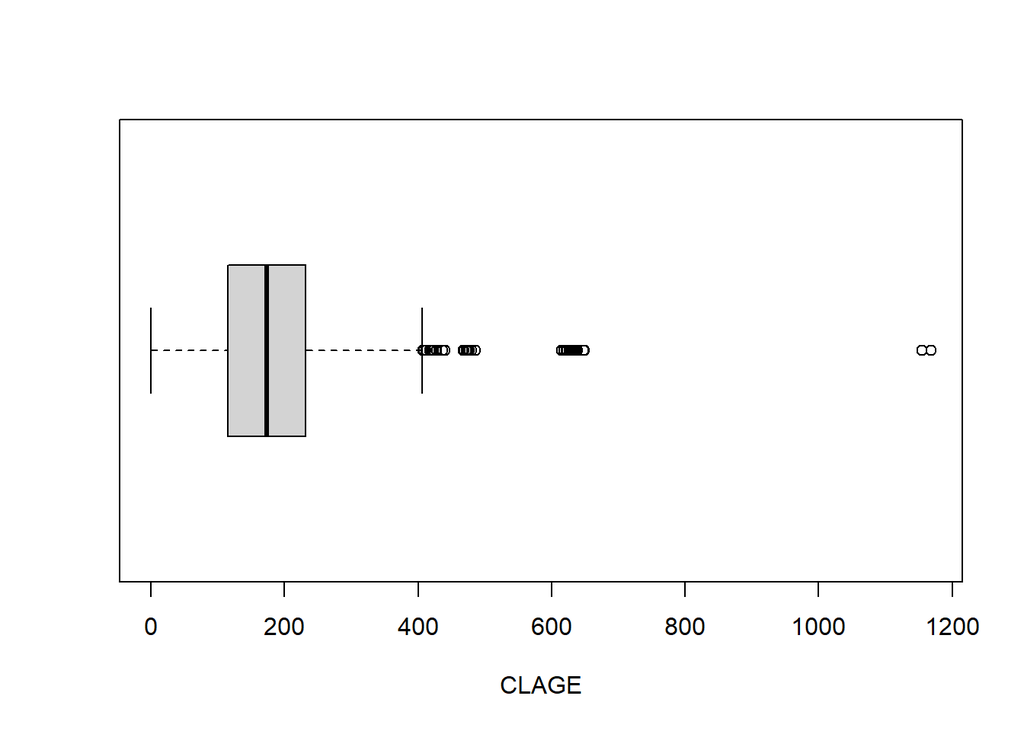

```r
boxplot(riesgocrediticio$CLAGE, horizontal = T, xlab = "CLAGE")
```

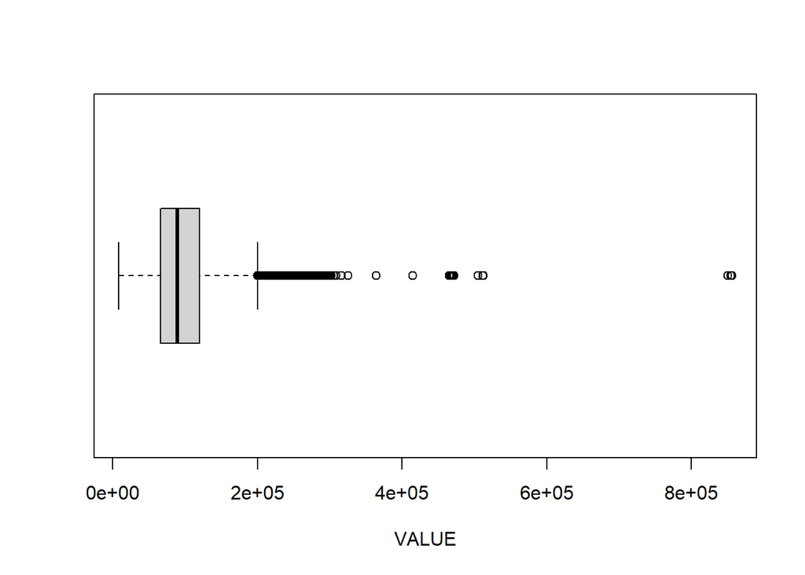

```r
boxplot(riesgocrediticio$VALUE, horizontal = T, xlab = "VALUE")
```

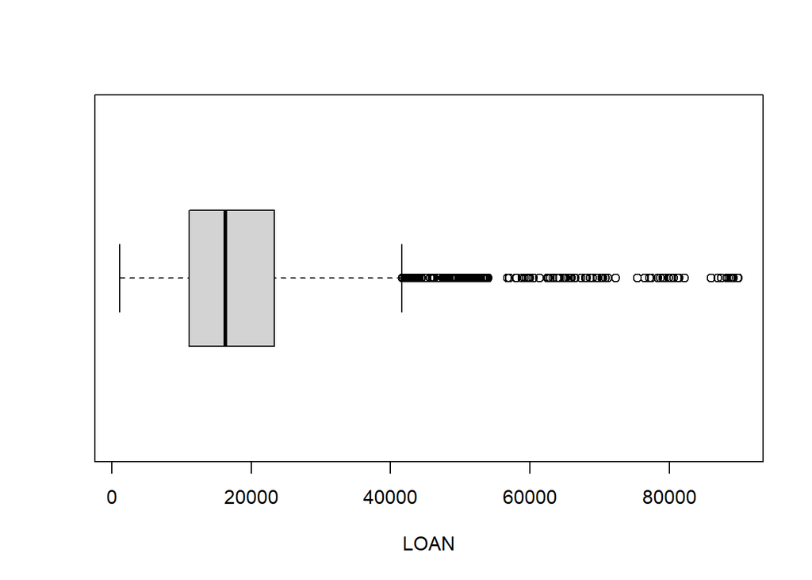

```r
boxplot(riesgocrediticio$LOAN, horizontal = T, xlab = "LOAN")
```

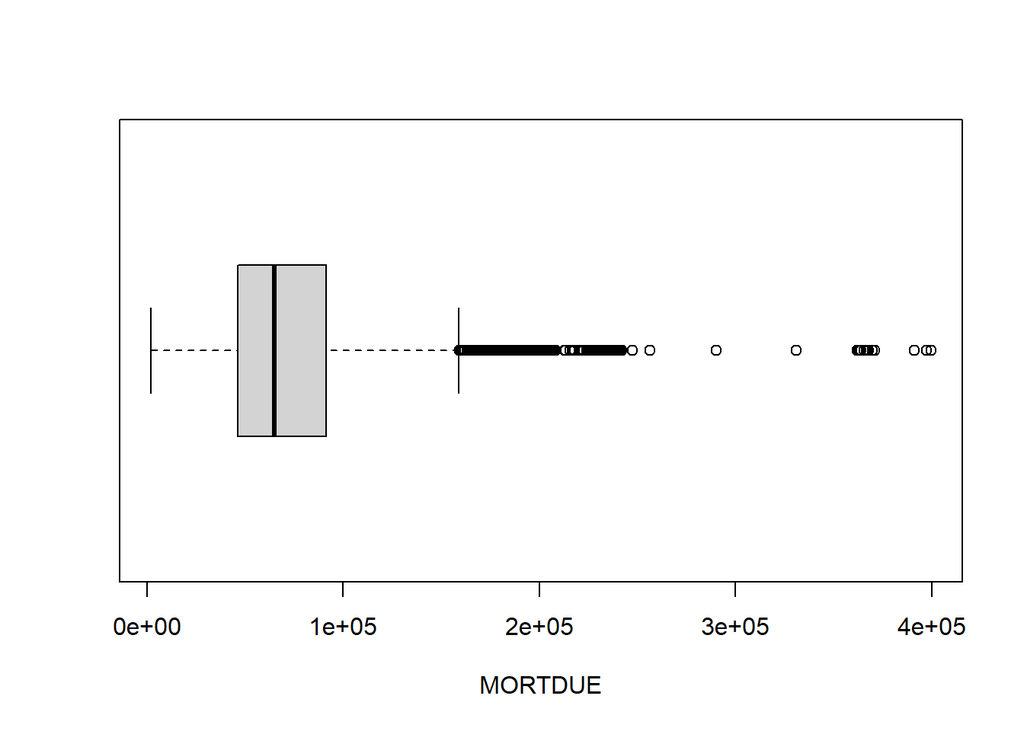

```r
boxplot(riesgocrediticio$MORTDUE, horizontal = T, xlab = "MORTDUE")
```

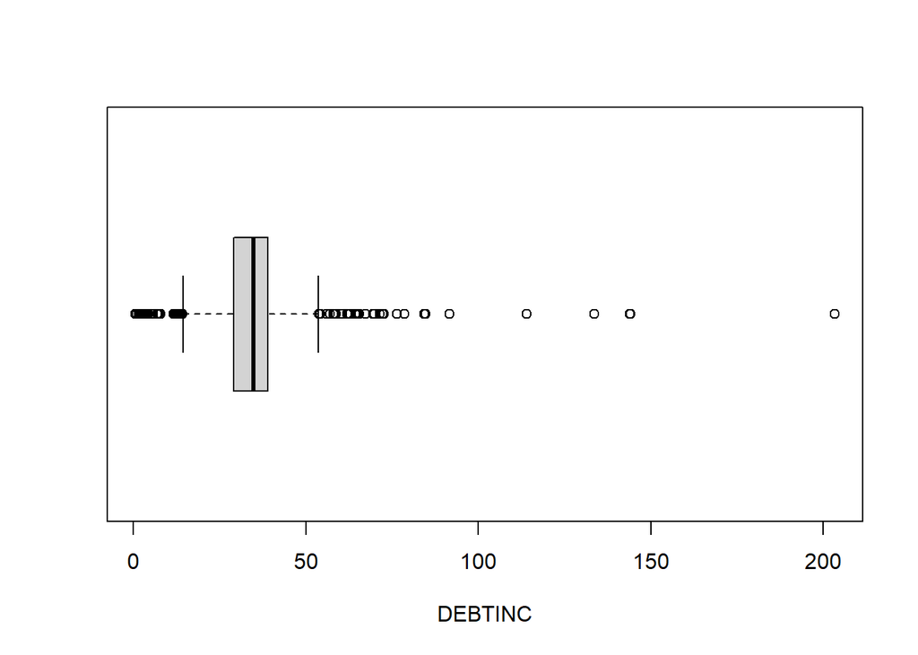

```r
boxplot(riesgocrediticio$DEBTINC, horizontal = T, xlab = "DEBTINC")
```

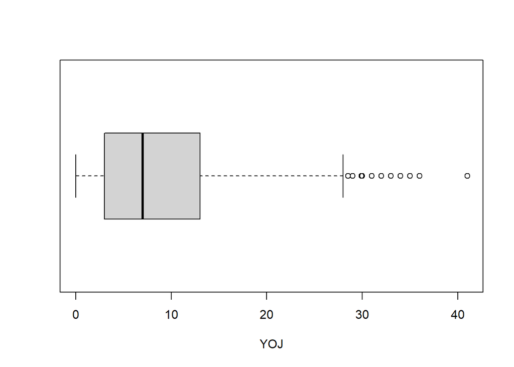

```r
boxplot(riesgocrediticio$YOJ, horizontal = T, xlab = "YOJ")
```

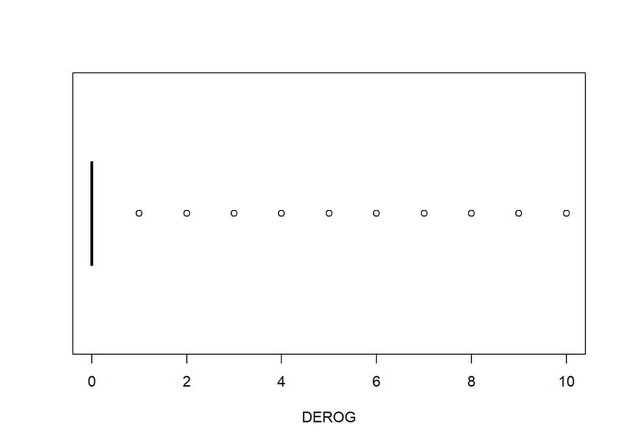

```r
boxplot(riesgocrediticio$DEROG, horizontal = T, xlab = "DEROG")
```

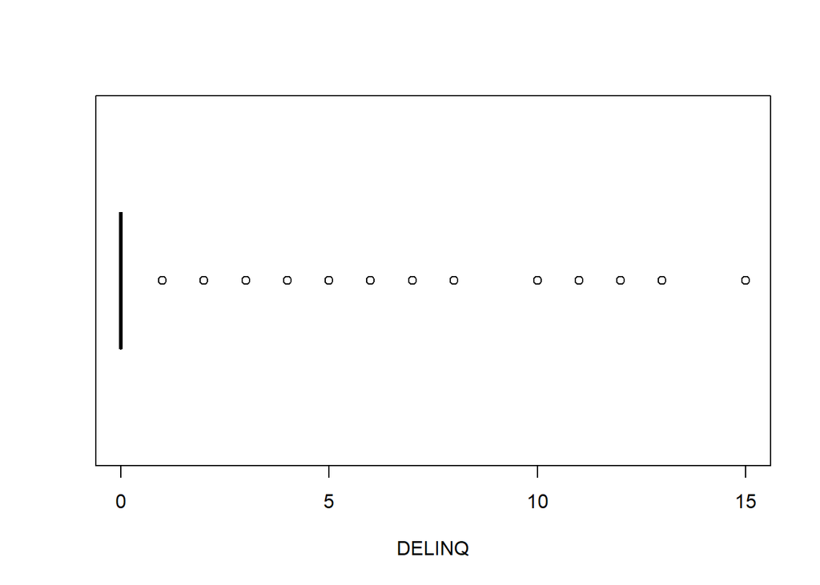

```r
boxplot(riesgocrediticio$DELINQ, horizontal = T, xlab = "DELINQ")
```

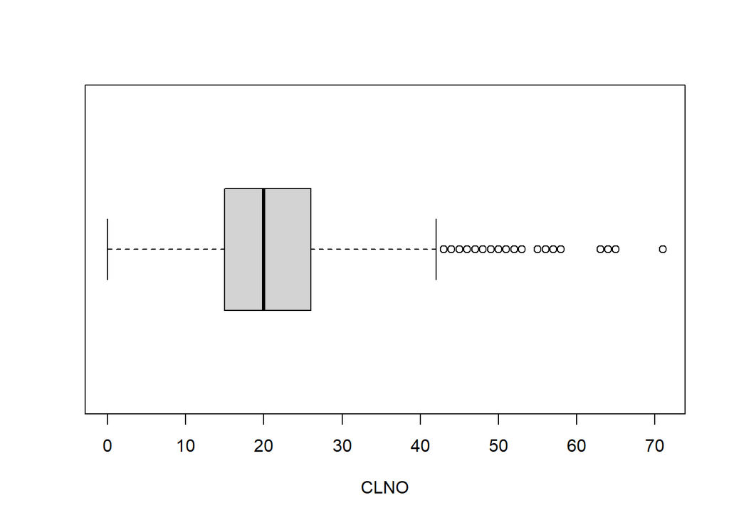

```r
boxplot(riesgocrediticio$CLNO, horizontal = T, xlab = "CLNO")
```

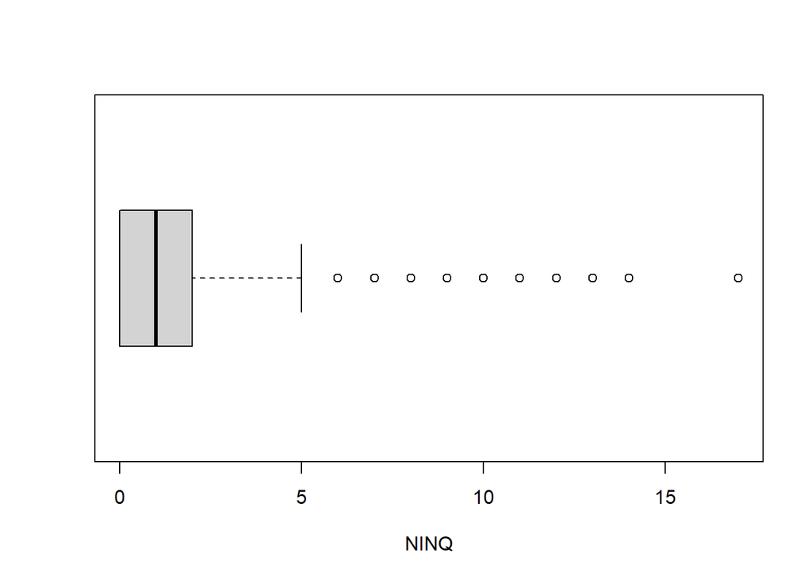

```r
boxplot(riesgocrediticio$NINQ, horizontal = T, xlab = "NINQ")
```

# 3 Datos faltantes, NA’s

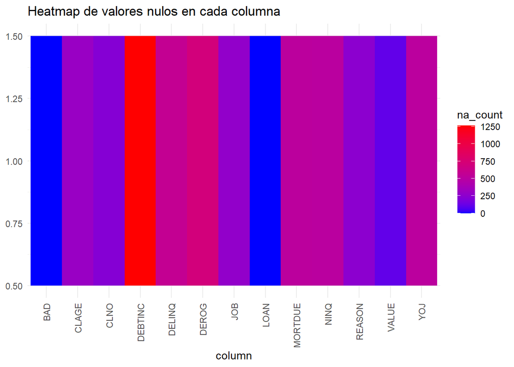

```r
# Crear un resumen de las NA por columna
na_summary <- colSums(is.na(riesgocrediticio))

# Crear un data frame con los nombres de las columnas y el número de NA
na_df <- data.frame(column = names(na_summary), na_count = na_summary)

# Plot del heatmap
ggplot(na_df, aes(x = column, y = 1, fill = na_count)) +
  geom_tile() +
  scale_fill_gradient(low = "blue", high = "red") +
  theme_minimal() +
  theme(axis.text.x = element_text(angle = 90, vjust = 0.5, hjust = 1)) +
  labs(title = "Heatmap de valores nulos en cada columna", y = NULL)
```

En las variables cualitativas el primer caso se trata de una variable dicotómica o binaria, pero la variable JOB tiene 6 categorías, entonces se usan 6-1=5 variables ficticias o dummy para describirla adecuadamente mediante variables dicotómicas. Por defecto lo codifica por orden alfabético pero como no es una clasificación de orden, no importa. Vemos que los 1 de las variables dummy no se solapan, quedando las categorías completamente separadas.

```r
riesgocrediticio %>%
 select(JOB) %>%
 table(exclude=NULL) %>%
 prop.table()
```

```
## JOB
##        Mgr     Office      Other    ProfExe      Sales       Self       <NA>
## 0.12869128 0.15906040 0.40067114 0.21409396 0.01828859 0.03238255 0.04681208
```

Aunque en este caso el porcentaje de NA’s para las variables categóricas es bastante bajo podemos modelar los datos faltantes añadiendo una salida que sustituya el valor NA, por ejemplo:“UNK” del inglés unknown, desconocido. Esto se hace para compensar el hecho de que la regresión logística no puede manejar valores NA.

```r
riesgocrediticio <- riesgocrediticio %>%
   mutate(JOB = as.character(JOB)) %>%
   mutate(JOB = as.factor(ifelse(is.na(JOB), 'UNK', JOB)))%>%
   mutate(REASON = as.character(REASON)) %>%
   mutate(REASON = as.factor(ifelse(is.na(REASON), 'UNK', REASON)))

riesgocrediticio %>%
 keep(is.factor) %>%
 summary()
```

```
##  BAD          REASON          JOB
##  0:4771   DebtCon:3928   Mgr    : 767
##  1:1189   HomeImp:1780   Office : 948
##           UNK    : 252   Other  :2388
##                          ProfExe:1276
##                          Sales  : 109
##                          Self   : 193
##                          UNK    : 279
```

```r
data <- riesgocrediticio[complete.cases(riesgocrediticio[c("JOB", "REASON")]), ]
dim(data)
```

```
## [1] 5960   13
```

```r
summary(data)
```

```
##  BAD           LOAN          MORTDUE           VALUE            REASON
##  0:4771   Min.   : 1100   Min.   :  2063   Min.   :  8000   DebtCon:3928
##  1:1189   1st Qu.:11100   1st Qu.: 46276   1st Qu.: 66076   HomeImp:1780
##           Median :16300   Median : 65019   Median : 89236   UNK    : 252
##           Mean   :18608   Mean   : 73761   Mean   :101776
##           3rd Qu.:23300   3rd Qu.: 91488   3rd Qu.:119824
##           Max.   :89900   Max.   :399550   Max.   :855909
##                           NA's   :518      NA's   :112
##       JOB            YOJ             DEROG             DELINQ
##  Mgr    : 767   Min.   : 0.000   Min.   : 0.0000   Min.   : 0.0000
##  Office : 948   1st Qu.: 3.000   1st Qu.: 0.0000   1st Qu.: 0.0000
##  Other  :2388   Median : 7.000   Median : 0.0000   Median : 0.0000
##  ProfExe:1276   Mean   : 8.922   Mean   : 0.2546   Mean   : 0.4494
##  Sales  : 109   3rd Qu.:13.000   3rd Qu.: 0.0000   3rd Qu.: 0.0000
##  Self   : 193   Max.   :41.000   Max.   :10.0000   Max.   :15.0000
##  UNK    : 279   NA's   :515      NA's   :708       NA's   :580
##      CLAGE             NINQ             CLNO         DEBTINC
##  Min.   :   0.0   Min.   : 0.000   Min.   : 0.0   Min.   :  0.5245
##  1st Qu.: 115.1   1st Qu.: 0.000   1st Qu.:15.0   1st Qu.: 29.1400
##  Median : 173.5   Median : 1.000   Median :20.0   Median : 34.8183
##  Mean   : 179.8   Mean   : 1.186   Mean   :21.3   Mean   : 33.7799
##  3rd Qu.: 231.6   3rd Qu.: 2.000   3rd Qu.:26.0   3rd Qu.: 39.0031
##  Max.   :1168.2   Max.   :17.000   Max.   :71.0   Max.   :203.3121
##  NA's   :308      NA's   :510      NA's   :222    NA's   :1267
```

Ahora hemos resuelto el problema de los valores faltantes de las variables categóricas.

Respecto a las variables continuas podemos ver que la varible “DEBTINC” es la que presenta una mayor cantidad significante de datos faltantes. Estudiemos entonces la posible eliminación de dicha variable para nuestro estudio.

```r
na_debtinc=sum(is.na(data$DEBTINC))
na_debtinc
```

```
## [1] 1267
```

```r
prop_na=na_debtinc/nrow(data)
prop_na
```

```
## [1] 0.2125839
```

Puesto que nos faltan más del 20% (~21.26%)de los datos en esa variable, estudiemos la correlación respecto al resto de variables cuantitativas.

```r
datos_DEBTINC=nrow(data)-na_debtinc
datos_DEBTINC
```

```
## [1] 4693
```

```r
datos=na.omit(data) #base de datos habiendo eliminado todas las observaciones de las que no tenemos datos en la columna de la variable DEBTINC
cor(datos[,-c(1,5,6)], datos$DEBTINC)
```

```
##                [,1]
## LOAN     0.14807415
## MORTDUE  0.18176257
## VALUE    0.12843745
## YOJ     -0.06188297
## DEROG    0.03895457
## DELINQ   0.04815206
## CLAGE   -0.05783920
## NINQ     0.15083198
## CLNO     0.14037528
## DEBTINC  1.00000000
```

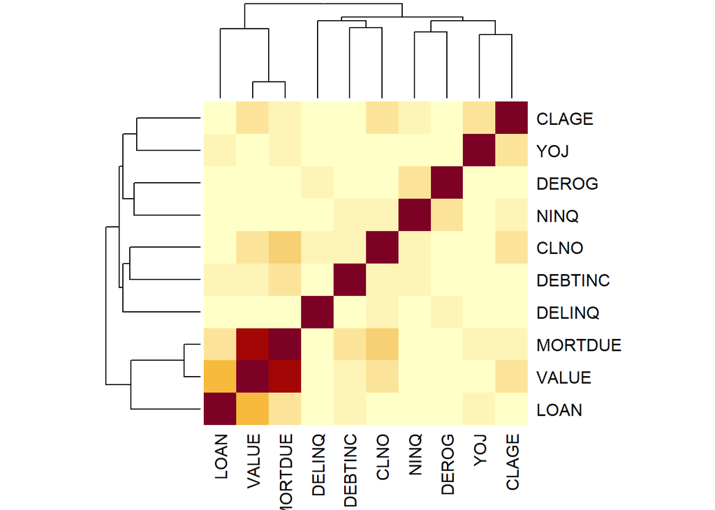

```r
heatmap(abs(cor(datos[,-c(1,5,6)])),scale="none")
```

Tras analizar los resultados numéricos y el mapa de calor en cuanto a la variable DEBTINC, podemos concluir que su correlación con el resto de variables es muy baja. Para no erradicarla del estudio hagamos dos modelos uno con este variable y otro sin ella.

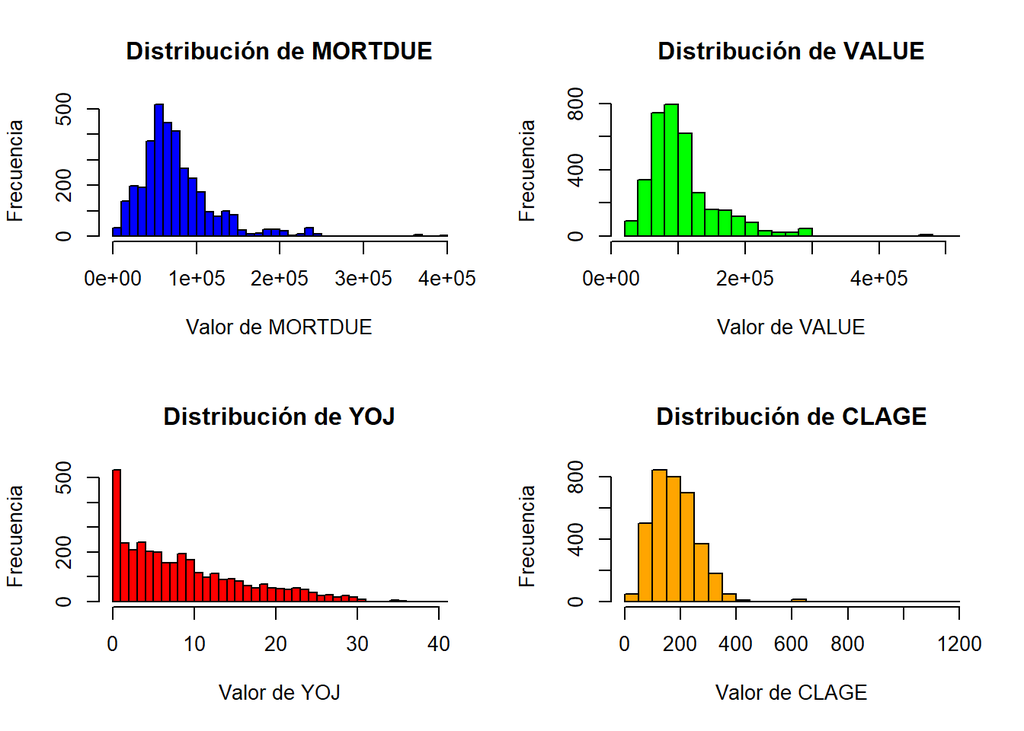

```r
# Configurar ventana grafica 2x2
par(mfrow = c(2, 2))

# Histograma de MORTDUE
hist(datos$MORTDUE, breaks = 30, col = "blue", border = "black",
     main = "Distribución de MORTDUE",
     xlab = "Valor de MORTDUE",
     ylab = "Frecuencia")

# Histograma de VALUE
hist(datos$VALUE, breaks = 30, col = "green", border = "black",
     main = "Distribución de VALUE",
     xlab = "Valor de VALUE",
     ylab = "Frecuencia")

# Histograma de YOJ
hist(datos$YOJ, breaks = 30, col = "red", border = "black",
     main = "Distribución de YOJ",
     xlab = "Valor de YOJ",
     ylab = "Frecuencia")

# Histograma de CLAGE
hist(datos$CLAGE, breaks = 30, col = "orange", border = "black",
     main = "Distribución de CLAGE",
     xlab = "Valor de CLAGE",
     ylab = "Frecuencia")
```

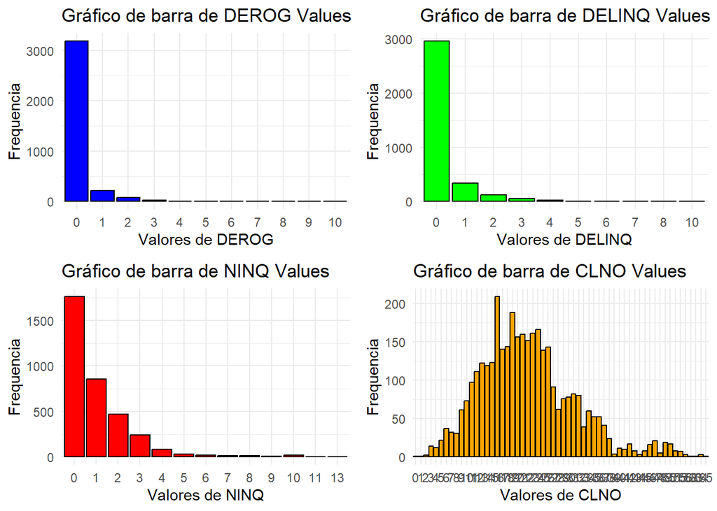

```r
# Grafico de barras para DEROG
p1 = ggplot(datos, aes(x = factor(DEROG))) +
  geom_bar(fill = "blue", color = "black") +
  labs(title = "Gráfico de barra de DEROG Values",
       x = "Valores de DEROG",
       y = "Frequencia") +
  theme_minimal()

# Grafico de barras para DELINQ
p2 = ggplot(datos, aes(x = factor(DELINQ))) +
  geom_bar(fill = "green", color = "black") +
  labs(title = "Gráfico de barra de DELINQ Values",
       x = "Valores de DELINQ",
       y = "Frequencia") +
  theme_minimal()

# Grafico de barras para NINQ
p3 = ggplot(datos, aes(x = factor(NINQ))) +
  geom_bar(fill = "red", color = "black") +
  labs(title = "Gráfico de barra de NINQ Values",
       x = "Valores de NINQ",
       y = "Frequencia") +
  theme_minimal()

# Grafico de barras para CLNO
p4 =ggplot(datos, aes(x = factor(CLNO))) +
  geom_bar(fill = "orange", color = "black") +
  labs(title = "Gráfico de barra de CLNO Values",
       x = "Valores de CLNO",
       y = "Frequencia") +
  theme_minimal()

# Organizar los graficos en un diseño 2x2
grid.arrange(p1, p2, p3, p4, ncol = 2)
```

```r
# Calcular la mediana de DEROG
mediana_DEROG <- median(datos$DEROG, na.rm = TRUE)

# Imputar los valores faltantes de DEROG con la mediana
datos$DEROG[is.na(datos$DEROG)] <- mediana_DEROG


# Calcular la mediana de DELINQ
mediana_DELINQ <- median(datos$DELINQ, na.rm = TRUE)

# Imputar los valores faltantes de DELINQ con la mediana
datos$DELINQ[is.na(datos$DELINQ)] <- mediana_DELINQ


# Calcular la mediana de NINQ
mediana_NINQ <- median(datos$NINQ, na.rm = TRUE)

# Imputar los valores faltantes de NINQ con la mediana
datos$NINQ[is.na(datos$NINQ)] <- mediana_NINQ

# Calcular la moda de CLNO
moda_CLNO <- datos %>%
  filter(!is.na(CLNO)) %>%
  count(CLNO) %>%
  arrange(desc(n)) %>%
  slice(1) %>%
  pull(CLNO)

# Imputar los valores faltantes de CLNO con la moda
datos$CLNO[is.na(datos$CLNO)] <- moda_CLNO
```

```r
sapply(datos, function(x) sum(is.na(x)))
```

```
##     BAD    LOAN MORTDUE   VALUE  REASON     JOB     YOJ   DEROG  DELINQ   CLAGE
##       0       0       0       0       0       0       0       0       0       0
##    NINQ    CLNO DEBTINC
##       0       0       0
```

Al tratar con valores faltantes, siempre se debe tener cuidado de no alterar significativamente las características estructurales de los datos originales. Una forma sencilla de verificar que nuestros datos mantienen su estructura general a través del resumen estadístico de los datos antes y después de que se completen los valores faltantes.

```r
summary(datos)
```

```
##  BAD           LOAN          MORTDUE           VALUE            REASON
##  0:3206   Min.   : 1700   Min.   :  5076   Min.   : 21144   DebtCon:2438
##  1: 309   1st Qu.:11900   1st Qu.: 48851   1st Qu.: 70989   HomeImp:1007
##           Median :16900   Median : 66590   Median : 94071   UNK    :  70
##           Mean   :19188   Mean   : 75623   Mean   :106876
##           3rd Qu.:23600   3rd Qu.: 92598   3rd Qu.:122175
##           Max.   :89900   Max.   :399412   Max.   :512650
##
##       JOB            YOJ             DEROG             DELINQ
##  Mgr    : 455   Min.   : 0.000   Min.   : 0.0000   Min.   : 0.0000
##  Office : 601   1st Qu.: 3.000   1st Qu.: 0.0000   1st Qu.: 0.0000
##  Other  :1317   Median : 7.000   Median : 0.0000   Median : 0.0000
##  ProfExe: 908   Mean   : 9.165   Mean   : 0.1465   Mean   : 0.2706
##  Sales  :  53   3rd Qu.:14.000   3rd Qu.: 0.0000   3rd Qu.: 0.0000
##  Self   : 100   Max.   :41.000   Max.   :10.0000   Max.   :10.0000
##  UNK    :  81
##      CLAGE                NINQ             CLNO          DEBTINC
##  Min.   :   0.4867   Min.   : 0.000   Min.   : 0.00   Min.   :  0.8381
##  1st Qu.: 118.6763   1st Qu.: 0.000   1st Qu.:16.00   1st Qu.: 29.3830
##  Median : 176.5303   Median : 0.000   Median :21.00   Median : 34.9805
##  Mean   : 181.0827   Mean   : 1.023   Mean   :21.95   Mean   : 34.1206
##  3rd Qu.: 230.2727   3rd Qu.: 2.000   3rd Qu.:27.00   3rd Qu.: 39.0058
##  Max.   :1168.2336   Max.   :13.000   Max.   :65.00   Max.   :144.1890
##
```

# 4 Codificación de variables categóricas

```r
datos$BAD=factor(datos$BAD, levels = c(0, 1), labels = c("No Moroso", "Moroso"))
contrasts(datos$BAD)
```

```
##           Moroso
## No Moroso      0
## Moroso         1
```

```r
contrasts(datos$REASON)
```

```
##         HomeImp UNK
## DebtCon       0   0
## HomeImp       1   0
## UNK           0   1
```

```r
contrasts(datos$JOB)
```

```
##         Office Other ProfExe Sales Self UNK
## Mgr          0     0       0     0    0   0
## Office       1     0       0     0    0   0
## Other        0     1       0     0    0   0
## ProfExe      0     0       1     0    0   0
## Sales        0     0       0     1    0   0
## Self         0     0       0     0    1   0
## UNK          0     0       0     0    0   1
```

# 5 División de los datos

Hacemos una división del 70% para el conjunto de entrenamiento y del 30% para el conjunto de prueba. Llamamos a los nuevos conjuntos de datos datos_entrenamiento y datos_prueba, respectivamente.

```r
set.seed(123) # Para reproducibilidad
indice <- sample(nrow(datos), round(nrow(datos)*0.7), replace = FALSE) # 70% de los datos para entrenamiento
datos_entrenamiento <- datos[indice, ]
datos_prueba <- datos[-indice, ]
```

clases de los conjuntos de datos:

```r
round(prop.table(table(select(datos, BAD), exclude = NULL)), 4) * 100
```

```
## BAD
## No Moroso    Moroso
##     91.21      8.79
```

```r
 round(prop.table(table(select(datos_entrenamiento, BAD), exclude = NULL)), 4) * 100
```

```
## BAD
## No Moroso    Moroso
##      91.1       8.9
```

```r
 round(prop.table(table(select(datos_prueba, BAD), exclude = NULL)), 4) * 100
```

```
## BAD
## No Moroso    Moroso
##     91.47      8.53
```

# 6 Regresión logística

```r
# Ajuste del modelo de regresion logistica
modelo_logistico <- glm(BAD ~ ., data=datos, family=binomial)
summary(modelo_logistico)
```

```
##
## Call:
## glm(formula = BAD ~ ., family = binomial, data = datos)
##
## Coefficients:
##                 Estimate Std. Error z value Pr(>|z|)
## (Intercept)   -5.038e+00  4.776e-01 -10.549  < 2e-16 ***
## LOAN          -1.808e-05  8.084e-06  -2.236  0.02533 *
## MORTDUE       -3.705e-06  3.441e-06  -1.077  0.28160
## VALUE          4.172e-06  2.969e-06   1.405  0.15998
## REASONHomeImp -1.214e-01  1.603e-01  -0.757  0.44882
## REASONUNK      7.261e-01  5.206e-01   1.395  0.16308
## JOBOffice     -6.784e-01  2.680e-01  -2.531  0.01137 *
## JOBOther      -5.672e-02  2.078e-01  -0.273  0.78490
## JOBProfExe    -3.719e-02  2.383e-01  -0.156  0.87598
## JOBSales       1.267e+00  4.446e-01   2.849  0.00439 **
## JOBSelf        7.092e-01  4.081e-01   1.738  0.08227 .
## JOBUNK        -2.145e+00  1.148e+00  -1.869  0.06159 .
## YOJ           -9.144e-03  1.004e-02  -0.911  0.36222
## DEROG          7.534e-01  1.018e-01   7.403 1.33e-13 ***
## DELINQ         7.584e-01  7.037e-02  10.777  < 2e-16 ***
## CLAGE         -5.577e-03  1.063e-03  -5.248 1.54e-07 ***
## NINQ           1.221e-01  3.818e-02   3.197  0.00139 **
## CLNO          -1.875e-02  8.072e-03  -2.322  0.02021 *
## DEBTINC        1.034e-01  1.044e-02   9.902  < 2e-16 ***
## ---
## Signif. codes:  0 '***' 0.001 '**' 0.01 '*' 0.05 '.' 0.1 ' ' 1
##
## (Dispersion parameter for binomial family taken to be 1)
##
##     Null deviance: 2092.6  on 3514  degrees of freedom
## Residual deviance: 1580.2  on 3496  degrees of freedom
## AIC: 1618.2
##
## Number of Fisher Scoring iterations: 7
```

```r
exp(coef(modelo_logistico))
```

```
##   (Intercept)          LOAN       MORTDUE         VALUE REASONHomeImp
##     0.0064856     0.9999819     0.9999963     1.0000042     0.8856851
##     REASONUNK     JOBOffice      JOBOther    JOBProfExe      JOBSales
##     2.0670594     0.5074040     0.9448576     0.9634911     3.5492014
##       JOBSelf        JOBUNK           YOJ         DEROG        DELINQ
##     2.0323518     0.1170357     0.9908973     2.1242050     2.1348923
##         CLAGE          NINQ          CLNO       DEBTINC
##     0.9944390     1.1298235     0.9814283     1.1089039
```

```r
tidy(modelo_logistico)
```

```
## # A tibble: 19 × 5
##    term             estimate  std.error statistic  p.value
##    <chr>               <dbl>      <dbl>     <dbl>    <dbl>
##  1 (Intercept)   -5.04       0.478        -10.5   5.13e-26
##  2 LOAN          -0.0000181  0.00000808    -2.24  2.53e- 2
##  3 MORTDUE       -0.00000370 0.00000344    -1.08  2.82e- 1
##  4 VALUE          0.00000417 0.00000297     1.41  1.60e- 1
##  5 REASONHomeImp -0.121      0.160         -0.757 4.49e- 1
##  6 REASONUNK      0.726      0.521          1.39  1.63e- 1
##  7 JOBOffice     -0.678      0.268         -2.53  1.14e- 2
##  8 JOBOther      -0.0567     0.208         -0.273 7.85e- 1
##  9 JOBProfExe    -0.0372     0.238         -0.156 8.76e- 1
## 10 JOBSales       1.27       0.445          2.85  4.39e- 3
## 11 JOBSelf        0.709      0.408          1.74  8.23e- 2
## 12 JOBUNK        -2.15       1.15          -1.87  6.16e- 2
## 13 YOJ           -0.00914    0.0100        -0.911 3.62e- 1
## 14 DEROG          0.753      0.102          7.40  1.33e-13
## 15 DELINQ         0.758      0.0704        10.8   4.41e-27
## 16 CLAGE         -0.00558    0.00106       -5.25  1.54e- 7
## 17 NINQ           0.122      0.0382         3.20  1.39e- 3
## 18 CLNO          -0.0187     0.00807       -2.32  2.02e- 2
## 19 DEBTINC        0.103      0.0104         9.90  4.07e-23
```

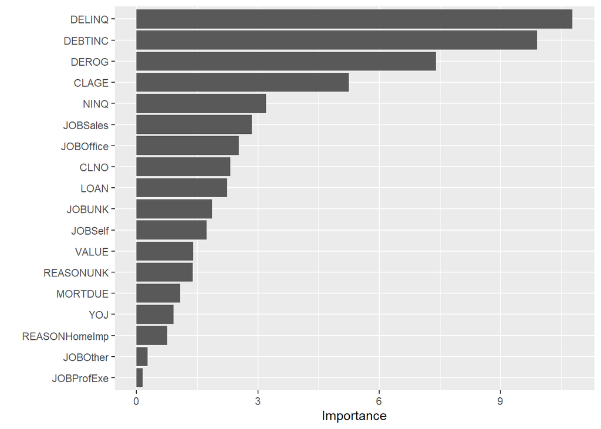

```r
vip(modelo_logistico,num_features=18)
```

```r
logistica_1 <- glm(BAD ~ LOAN + MORTDUE + VALUE + REASON + JOB + YOJ + DEROG + DELINQ + CLAGE + NINQ + CLNO, data = datos_entrenamiento, family = "binomial")

summary(logistica_1)
```

```
##
## Call:
## glm(formula = BAD ~ LOAN + MORTDUE + VALUE + REASON + JOB + YOJ +
##     DEROG + DELINQ + CLAGE + NINQ + CLNO, family = "binomial",
##     data = datos_entrenamiento)
##
## Coefficients:
##                 Estimate Std. Error z value Pr(>|z|)
## (Intercept)   -1.357e+00  3.649e-01  -3.719 0.000200 ***
## LOAN          -1.711e-05  9.388e-06  -1.823 0.068333 .
## MORTDUE        7.874e-07  3.863e-06   0.204 0.838473
## VALUE          3.336e-06  3.345e-06   0.997 0.318528
## REASONHomeImp -1.415e-01  1.897e-01  -0.746 0.455871
## REASONUNK      1.066e+00  4.863e-01   2.191 0.028455 *
## JOBOffice     -4.767e-01  3.105e-01  -1.535 0.124809
## JOBOther      -7.813e-02  2.464e-01  -0.317 0.751220
## JOBProfExe    -6.248e-02  2.755e-01  -0.227 0.820558
## JOBSales       1.830e+00  4.769e-01   3.836 0.000125 ***
## JOBSelf        1.197e+00  4.242e-01   2.821 0.004794 **
## JOBUNK        -1.498e+01  5.395e+02  -0.028 0.977843
## YOJ           -7.408e-03  1.227e-02  -0.604 0.546172
## DEROG          7.512e-01  1.124e-01   6.686 2.30e-11 ***
## DELINQ         7.547e-01  7.773e-02   9.709  < 2e-16 ***
## CLAGE         -7.649e-03  1.292e-03  -5.920 3.21e-09 ***
## NINQ           1.705e-01  4.426e-02   3.851 0.000118 ***
## CLNO          -2.061e-02  9.534e-03  -2.161 0.030669 *
## ---
## Signif. codes:  0 '***' 0.001 '**' 0.01 '*' 0.05 '.' 0.1 ' ' 1
##
## (Dispersion parameter for binomial family taken to be 1)
##
##     Null deviance: 1477.4  on 2459  degrees of freedom
## Residual deviance: 1161.7  on 2442  degrees of freedom
## AIC: 1197.7
##
## Number of Fisher Scoring iterations: 16
```

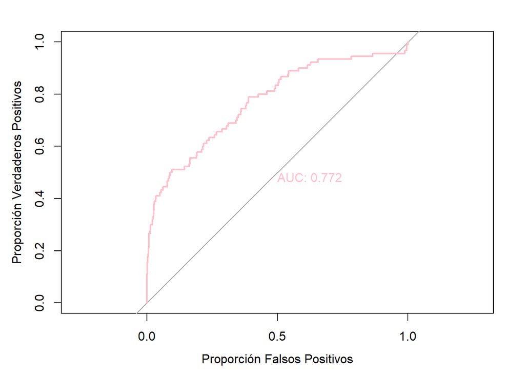

```r
# Realizar predicciones con el modelo ya entrenado
logistica_pred = predict(modelo_logistico, type = "response", newdata = datos_prueba)

df_pred = data.frame(BAD = datos_prueba$BAD, Probabilidad = logistica_pred)
tf = table(round(modelo_logistico$fitted.values,2))

logistica_roc <- roc(datos_prueba$BAD, logistica_pred, plot = TRUE,
                     xlab = "Proporción Falsos Positivos",
                     ylab = "Proporción Verdaderos Positivos", col = "pink", lwd = 2,
                     print.auc = TRUE, legacy.axes = TRUE)
```

```r
roc_data <- roc(datos_prueba$BAD, logistica_pred)
# Umbral óptimo
umbral_optimo <- coords(roc_data, "best", ret = "threshold", best.method = "youden") #0.1428537


# Obtener las medidas de evaluación
medidas <- coords(roc_data, ret = c("threshold", "accuracy", "specificity", "sensitivity", "youden", "tp", "tn", "fp", "fn"))
```

```r
predicciones_prob <- predict (modelo_logistico , newdata = datos_prueba , type = "response")
umbral_optimo <- 0.1428537
predicciones <- factor ( ifelse (predicciones_prob > umbral_optimo , " moroso ", "no moroso ") )
# Crear la matriz de confusión
matriz_confusion <- table (datos_prueba $BAD , predicciones , dnn = c(" observaciones", " predicciones ") )

# Reordenar las filas para que la primera casilla de la matriz sea "moroso,moroso"
matriz_confusion_reordenada <- matriz_confusion[c("Moroso", "No Moroso"), ]

# Mostrar la matriz de confusion reordenada
print("Matriz de confusión reordenada:")
```

```
## [1] "Matriz de confusión reordenada:"
```

```r
print(matriz_confusion_reordenada)
```

```
##                predicciones
##  observaciones  moroso  no moroso
##      Moroso          46         44
##      No Moroso       93        872
```

```r
# Crear una nueva variable indicadora para JOBOffice
datos_significativa <- datos %>%
  mutate(JOBOffice = ifelse(JOB == "Office", 1, 0))

# Verificar la creación de la nueva variable
head(datos_significativa)
```

```
##          BAD LOAN MORTDUE  VALUE  REASON    JOB YOJ DEROG DELINQ     CLAGE NINQ
## 6     Moroso 1700   30548  40320 HomeImp  Other   9     0      0 101.46600    1
## 8     Moroso 1800   28502  43034 HomeImp  Other  11     0      0  88.76603    0
## 20 No Moroso 2300  102370 120953 HomeImp Office   2     0      0  90.99253    0
## 26    Moroso 2400   34863  47471 HomeImp    Mgr  12     0      0  70.49108    1
## 27 No Moroso 2400   98449 117195 HomeImp Office   4     0      0  93.81177    0
## 35 No Moroso 2900  103949 112505 HomeImp Office   1     0      0  96.10233    0
##    CLNO  DEBTINC JOBOffice
## 6     8 37.11361         0
## 8     8 36.88489         0
## 20   13 31.58850         1
## 26   21 38.26360         0
## 27   13 29.68183         1
## 35   13 30.05114         1
```

Realizamos division de datos para los nuevos datos

```r
set.seed(123) # Para reproducibilidad
indice_significativa <- sample(nrow(datos_significativa), round(nrow(datos)*0.7), replace = FALSE) # 70% de los datos para entrenamiento
datos_entrenamiento_significativa <- datos_significativa[indice, ]
datos_prueba_significativa <- datos_significativa[-indice, ]
```

```r
modelo_logistico_significativa <- glm(BAD ~ JOBOffice + DEROG + DELINQ + CLAGE + DEBTINC, data = datos_entrenamiento_significativa, family = "binomial")

summary(modelo_logistico_significativa)
```

```
##
## Call:
## glm(formula = BAD ~ JOBOffice + DEROG + DELINQ + CLAGE + DEBTINC,
##     family = "binomial", data = datos_entrenamiento_significativa)
##
## Coefficients:
##              Estimate Std. Error z value Pr(>|z|)
## (Intercept) -5.215425   0.488766 -10.671  < 2e-16 ***
## JOBOffice   -0.678617   0.250901  -2.705  0.00684 **
## DEROG        0.822433   0.118036   6.968 3.22e-12 ***
## DELINQ       0.718574   0.079243   9.068  < 2e-16 ***
## CLAGE       -0.007596   0.001254  -6.059 1.37e-09 ***
## DEBTINC      0.102212   0.011805   8.658  < 2e-16 ***
## ---
## Signif. codes:  0 '***' 0.001 '**' 0.01 '*' 0.05 '.' 0.1 ' ' 1
##
## (Dispersion parameter for binomial family taken to be 1)
##
##     Null deviance: 1477.4  on 2459  degrees of freedom
## Residual deviance: 1116.9  on 2454  degrees of freedom
## AIC: 1128.9
##
## Number of Fisher Scoring iterations: 6
```

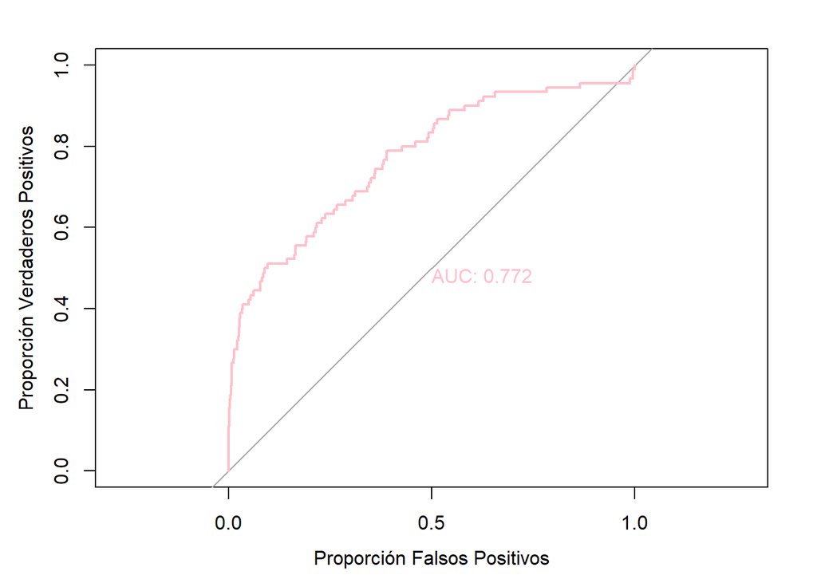

```r
logistica_pred_significativa = predict(modelo_logistico_significativa, type = "response", newdata = datos_prueba_significativa)

df_pred = data.frame(BAD = datos_prueba_significativa$BAD, Probabilidad = logistica_pred_significativa)
tf = table(round(modelo_logistico$fitted.values,2))

logistica_roc_significativa <- roc(datos_prueba$BAD, logistica_pred, plot = TRUE,
                     xlab = "Proporción Falsos Positivos",
                     ylab = "Proporción Verdaderos Positivos", col = "pink", lwd = 2,
                     print.auc = TRUE, legacy.axes = TRUE)
```

```r
roc_data_significativa <- roc(datos_prueba_significativa$BAD, logistica_pred_significativa)
# Umbral óptimo
umbral_optimo_significativa <- coords(roc_data_significativa, "best", ret = "threshold", best.method = "youden") #0.1428537


# Obtener las medidas de evaluación
medidas_significativa <- coords(roc_data_significativa, ret = c("threshold", "accuracy", "specificity", "sensitivity", "youden", "tp", "tn", "fp", "fn"))
```

```r
predicciones_prob_significativa <- predict (modelo_logistico_significativa , newdata = datos_prueba_significativa , type = "response")
umbral_optimo_significativa <- 0.1419092
predicciones_significativa <- factor ( ifelse (predicciones_prob_significativa > umbral_optimo_significativa , " moroso ", "no moroso ") )
# Crear la matriz de confusión
matriz_confusion_significativa <- table (datos_prueba_significativa$BAD , predicciones_significativa , dnn = c(" observaciones", " predicciones ") )

# Reordenar las filas para que la primera casilla de la matriz sea "moroso,moroso"
matriz_confusion_reordenada_significativa <- matriz_confusion_significativa[c("Moroso", "No Moroso"), ]

# Mostrar la matriz de confusión reordenada
print("Matriz de confusión reordenada:")
```

```
## [1] "Matriz de confusión reordenada:"
```

```r
print(matriz_confusion_reordenada_significativa)
```

```
##                predicciones
##  observaciones  moroso  no moroso
##      Moroso          48         42
##      No Moroso       93        872
```

```r
# Ajuste del modelo de redes neuronales
set.seed(123)
modelo_nnet <- nnet(BAD ~ LOAN + MORTDUE + VALUE + REASON + JOB + YOJ + DEROG + DELINQ + CLAGE + NINQ + CLNO + DEBTINC, data=datos_entrenamiento, size=10, maxit=200, decay=0.05)
# Predicciones con el modelo de redes neuronales
predicciones_nnet <- predict(modelo_nnet, datos_prueba, type="class")

# Matriz de confusión del modelo de redes neuronales en los datos de prueba
matriz_confusion_nnet <- table(predicciones_nnet, datos_prueba$BAD)
print(matriz_confusion_nnet)
```

```
##
## predicciones_nnet No Moroso Moroso
##         Moroso            5     24
##         No Moroso       960     66
```

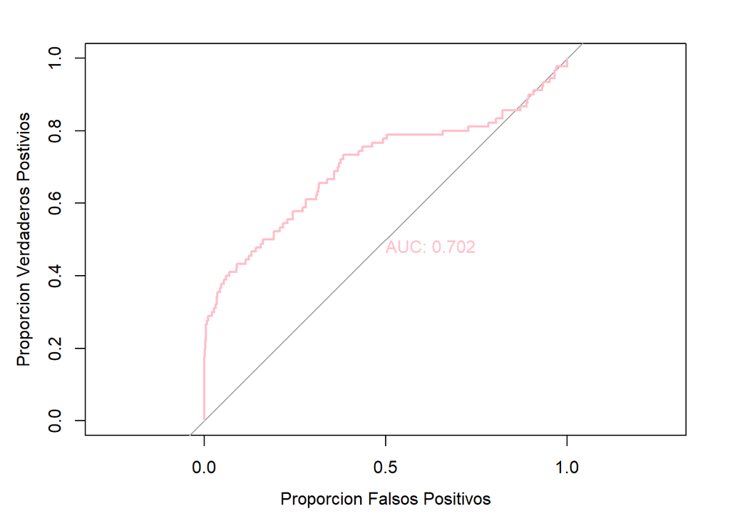

```r
prediccion_nnet <- predict(modelo_nnet, datos_prueba, type="raw")
nnet_roc= roc(datos_prueba$BAD, prediccion_nnet, plot = TRUE,
               xlab = "Proporcion Falsos Positivos",
    ylab = "Proporcion Verdaderos Postivios", col = "pink", lwd = 2,
    print.auc = TRUE, legacy.axes = TRUE)
```

```r
# Ajuste del modelo de redes neuronales
set.seed(123) # Para reproducibilidad
modelo_nnet1 <- nnet(BAD ~ LOAN + MORTDUE + VALUE + REASON + JOB + YOJ + DEROG + DELINQ + CLAGE + NINQ + CLNO + DEBTINC, data=datos_entrenamiento, size=10, maxit=300, decay=0.45)
# Predicciones con el modelo de redes neuronales
predicciones_nnet1 <- predict(modelo_nnet1, datos_prueba, type="class")

# Matriz de confusión del modelo de redes neuronales en los datos de prueba
matriz_confusion_nnet1 <- table(predicciones_nnet1, datos_prueba$BAD)
print(matriz_confusion_nnet1)
```

```
##
## predicciones_nnet1 No Moroso Moroso
##          Moroso            8     21
##          No Moroso       957     69
```

```r
# Reordenar las filas para que la primera casilla de la matriz sea "moroso,moroso"
matriz_confusion_nnet1_reordenada <- matriz_confusion_nnet1[c("Moroso", "No Moroso"), ]

# Mostrar la matriz de confusión reordenada
print("Matriz de confusión reordenada:")
```

```
## [1] "Matriz de confusión reordenada:"
```

```r
print(matriz_confusion_nnet1_reordenada)
```

```
##
## predicciones_nnet1 No Moroso Moroso
##          Moroso            8     21
##          No Moroso       957     69
```

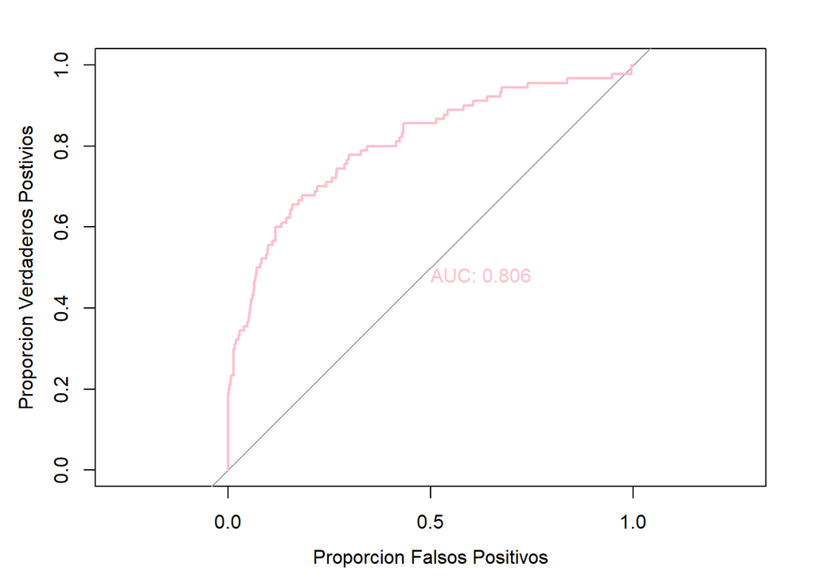

```r
prediccion_nnet1 <- predict(modelo_nnet1, datos_prueba, type="raw")
nnet_roc1= roc(datos_prueba$BAD, prediccion_nnet1, plot = TRUE,
               xlab = "Proporcion Falsos Positivos",
    ylab = "Proporcion Verdaderos Postivios", col = "pink", lwd = 2,
    print.auc = TRUE, legacy.axes = TRUE)
```

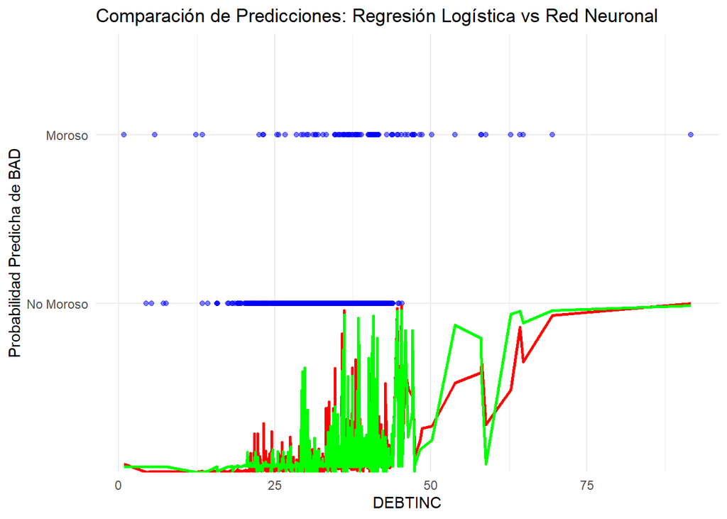

```r
# Gráficos comparativos
ggplot(datos_prueba, aes(x = DEBTINC, y=BAD))+
  geom_point(color = "blue", alpha = 0.5) +
  geom_line(aes(y = predicciones_prob), color = "red", size = 1) +
  geom_line(aes(y = prediccion_nnet), color = "green", size = 1) +
  labs(title = "Comparación de Predicciones: Regresión Logística vs Red Neuronal",
       x = "DEBTINC",
       y = "Probabilidad Predicha de BAD") +
  theme_minimal()
```

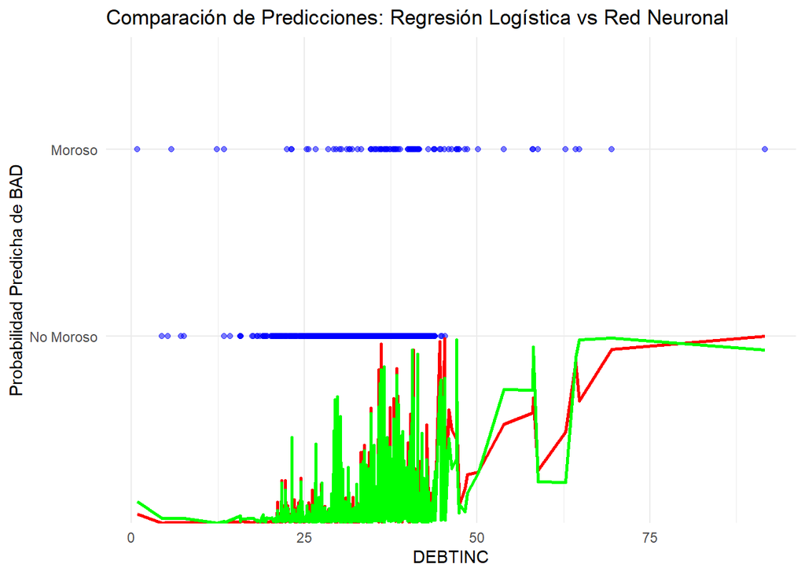

```r
ggplot(datos_prueba, aes(x = DEBTINC, y=BAD))+
  geom_point(color = "blue", alpha = 0.5) +
  geom_line(aes(y = predicciones_prob), color = "red", size = 1) +
  geom_line(aes(y = prediccion_nnet1), color = "green", size = 1) +
  labs(title = "Comparación de Predicciones: Regresión Logística vs Red Neuronal",
       x = "DEBTINC",
       y = "Probabilidad Predicha de BAD") +
  theme_minimal()
```